# 07. 머신 러닝(Machine Learning) 개요

### 5) 소프트맥스 회귀(Softmax Regression)

다중 클래스 분류를 설명하기 위해 예를 들었던 품종 분류 문제입니다.

#### (1) 아이리스 품종 데이터에 대한 이해

```python
import pandas as pd
data = pd.read_csv('iris.csv',encoding='latin1')
```

```python
print(len(data)) # 총 샘플의 개수 출력
print(data[:5]) # 샘플 중 5개 출력
```

```
150
   Id  SepalLengthCm  SepalWidthCm  PetalLengthCm  PetalWidthCm      Species
0   1            5.1           3.5            1.4           0.2  Iris-setosa
1   2            4.9           3.0            1.4           0.2  Iris-setosa
2   3            4.7           3.2            1.3           0.2  Iris-setosa
3   4            4.6           3.1            1.5           0.2  Iris-setosa
4   5            5.0           3.6            1.4           0.2  Iris-setosa
```

Species열은 몇 가지 품종으로 구성되어져 있는지 출력해보겠습니다.

```python
print("품종 종류:", data["Species"].unique(), sep="\n")
# 중복을 허용하지 않고, 있는 데이터의 모든 종류를 출력
```

```
품종 종류:
['Iris-setosa' 'Iris-versicolor' 'Iris-virginica']
```

즉, 이번 데이터를 가지고 푸는 문제는 주어진 샘플 데이터의 4개의 속성으로부터 3개 중 어떤 품종인지를 예측하는 문제가 되겠습니다.

3개의 품종이 4개의 속성에 대해서 어떤 분포를 가지고 있는지 시각화해봅시다.

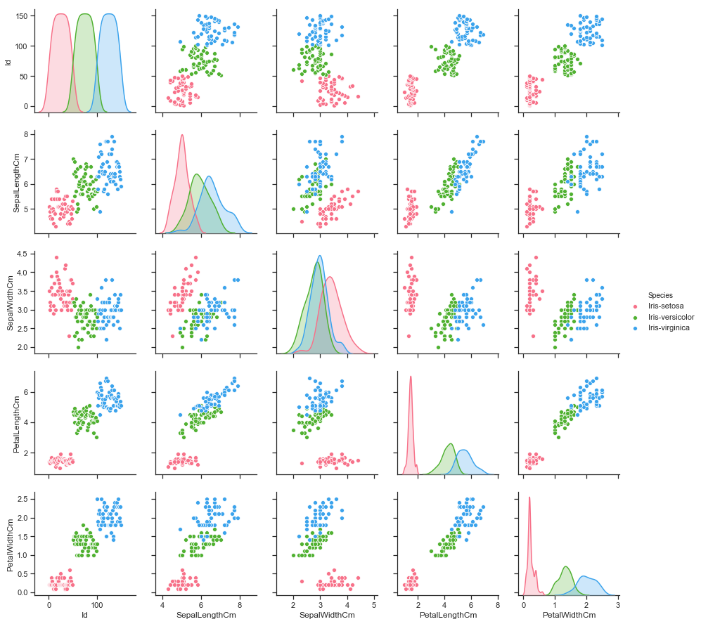

```python
import seaborn as sns
#del data['Id'] # 인덱스 열 삭제
sns.set(style="ticks", color_codes=True)
g = sns.pairplot(data, hue="Species", palette="husl")
```

pairplot은 데이터프레임을 인수로 받아 데이터프레임의 각 열의 조합에 따라서 산점도(scatter plot)을 그립니다.

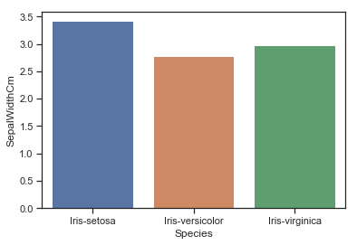

```python
sns.barplot(data['Species'], data['SepalWidthCm'], ci=None)
# 각 종과 특성에 대한 연관 관계
```

barplot을 통해 종과 특성에 대한 연관관계를 출력할 수도 있습니다.

150개의 샘플 데이터 중에서 각 품종인 Iris-setosa, Iris-versicolor, Iris-virginica을 나타내는 데이터가 몇 개씩 있는지 확인해보겠습니다. 즉, Species열에서 각 품종이 몇 개있는지 확인합니다.

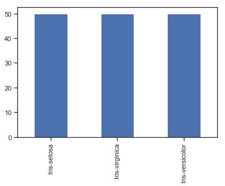

```python
import matplotlib.pyplot as plt
data['Species'].value_counts().plot(kind='bar')
```

데이터에 대한 구성을 파악하였다면, 이제 소프트맥스 회귀 모델을 구성하기 위해 전처리를 진행해야 합니다.

우선 Species열에 대해서 전부 수치화를 진행할 필요가 있습니다. 우선 원-핫 인코딩을 수행하기 전에 정수 인코딩을 수행합니다. 그리고 정상적으로 정수 인코딩이 수행되었는지 확인하기 위하여 다시 한 번 값의 분포를 출력합니다.

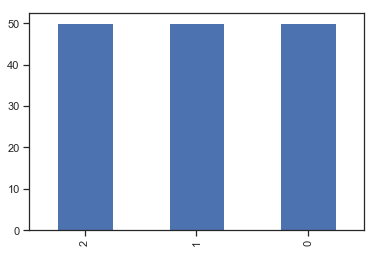

```python
data['Species'] = data['Species'].replace(['Iris-virginica','Iris-setosa','Iris-versicolor'],[0,1,2])
# Iris-virginica는 0, Iris-setosa는 1, Iris-versicolor는 2가 됨.
data['Species'].value_counts().plot(kind='bar')
```

이제 특성과 품종을 각각 종속 변수와 독립 변수 데이터로 분리하는 작업을 수행하고, 정확하게 분리가 되었는지 확인하기 위해 데이터 중 5개씩만 출력해보겠습니다.

```python
from sklearn.model_selection import train_test_split
data_X = data[['SepalLengthCm', 'SepalWidthCm', 'PetalLengthCm', 'PetalWidthCm']].values # X 데이터에 해당됩니다. X는 총 4개입니다.
data_y = data['Species'].values # Y 데이터에 해당됩니다. 예측해야하는 값입니다.

print(data_X[:5]) #X에 해당되는 데이터를 10개만 출력합니다.
print(data_y[:5]) #y에 해당되는 데이터를 10개만 출력합니다.
```

```
[[5.1 3.5 1.4 0.2]
 [4.9 3.  1.4 0.2]
 [4.7 3.2 1.3 0.2]
 [4.6 3.1 1.5 0.2]
 [5.  3.6 1.4 0.2]]
[1 1 1 1 1]
```

이제 훈련 데이터와 테스트 데이터의 분리와 원-핫 인코딩을 수행해보겠습니다.

```python
(X_train, X_test, y_train, y_test) = train_test_split(data_X, data_y, train_size=0.8, random_state=1)
# 훈련 데이터와 테스트 데이터를 8:2로 나눕니다. 또한 데이터의 순서를 섞습니다.
from keras.utils import np_utils
y_train = np_utils.to_categorical(y_train)
y_test = np_utils.to_categorical(y_test)
# 훈련 데이터와 테스트 데이터에 대해서 원-핫 인코딩
print(y_train[:5])
print(y_test[:5])
```

```
[[0. 0. 1.]
 [1. 0. 0.]
 [0. 0. 1.]
 [1. 0. 0.]
 [1. 0. 0.]]
[[0. 1. 0.]
 [0. 0. 1.]
 [0. 0. 1.]
 [0. 1. 0.]
 [1. 0. 0.]]
```

이제 전처리 단계가 모두 끝이 났습니다.

#### (2) 소프트맥스 회귀

```python
from keras.models import Sequential # 케라스의 Sequential()을 임포트
from keras.layers import Dense # 케라스의 Dense()를 임포트
from keras import optimizers # 케라스의 옵티마이저를 임포트

model=Sequential()
model.add(Dense(3, input_dim=4, activation='softmax'))
sgd=optimizers.SGD(lr=0.01)
# 학습률(learning rate, lr)은 0.01로 합니다.
model.compile(loss='categorical_crossentropy', optimizer='adam',metrics=['accuracy'])
# 옵티마이저는 경사하강법의 일종인 adam을 사용합니다.
# 손실 함수(Loss function)은 평균제곱오차 크로스 엔트로피 함수를 사용합니다.
history=model.fit(X_train,y_train, batch_size=1, epochs=200, validation_data=(X_test, y_test))
# 주어진 X와 y데이터에 대해서 오차를 최소화하는 작업을 200번 시도합니다.
```

```
Train on 120 samples, validate on 30 samples
```

함수로는 소프트맥스 함수를 사용하므로 activation에는 softmax를 기재해줍니다.

오차 함수로는 크로스 엔트로피 함수를 사용합니다. 이진 분류 문제에서는 binary_crossentropy를 사용하였지만, 다중 클래스 분류 문제에서는 'categorical_crossentropy를 기재해주어야 합니다. 옵티마이저로는 경사 하강법의 일종인 adam을 사용합니다. 전체 데이터에 대한 훈련 횟수는 200회로 주었습니다.

이번에는 테스트 데이터를 별도로 분리해서 평가에 사용하였는데, validation_data=()에 테스트 데이터를 기재해주면 실제로는 훈련에는 반영되지 않으면서 각 훈련 횟수마다 테스트 데이터에 대한 정확도를 출력합니다. 즉, 정확도가 전체 데이터에 대한 훈련 1회(1 에포크)마다 측정되고는 있지만 기계는 저 데이터를 가지고는 가중치를 업데이트하지 않습니다. 이해가 되지 않는다면 뒤의 로이터 뉴스 분류하기 챕터에서 다시 설명하므로 여기서는 넘어가도 좋습니다.

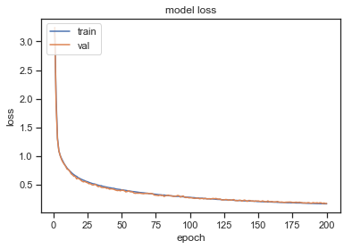

```python
epochs = range(1, len(history.history['acc']) + 1)
plt.plot(epochs, history.history['loss'])
plt.plot(epochs, history.history['val_loss'])
plt.title('model loss')
plt.ylabel('loss')
plt.xlabel('epoch')
plt.legend(['train', 'val'], loc='upper left')
plt.show()
```

```python
print("\n 테스트 정확도: %.4f" % (model.evaluate(X_test, y_test)[1]))
```

```
 테스트 정확도: 0.9667
```

### 6) 인공 신경망 다이어그램

n개의 특성을 가지고 m개의 클래스를 분류하는 소프트맥스 회귀를 뒤에서 배우게 되는 인공 신경망의 형태로 표현하면 다음과 같습니다.

[figure not shown]

사실 위의 그림은 앞서 소프트맥스 함수를 사용하기 위해 설명했던 아래의 그림에서 특성의 개수를 n으로 하고, 클래스의 개수를 m으로 일반화한 뒤에 그림을 좀 더 요약해서 표현한 것으로 봐도 무방합니다.

[figure not shown]